# W02: Reflection on Fundamentals of Machine Learning

Reflections and Hands-On Lab

Author

Mickyas Shawel

Published

June 16, 2026

```r
library(tidyverse)
library(broom)
```

# 1 Introduction

**NotePurpose of This Report**

This report reflects on the fundamentals of machine learning, the `tidymodels` ecosystem, MLOps, and hands-on modeling practice using base R and marketing data. The goal is to connect machine learning concepts with practical analysis and professional reporting through Quarto.

# 2 Step 1: Introduction to `tidymodels`

## 2.1 Prompt

In Step 1, the textbook authors made a case for a new approach in machine learning with the `tidymodels` package. Summarize the video presentation.

## 2.2 Response

The video presentation explained that machine learning in R has become more organized and consistent through the `tidymodels` ecosystem. Instead of using many unrelated modeling functions with different operations `tidymodels` provides a unified approach for building, evaluating, and comparing models.

The main idea is that machine learning should follow a clear workflow. This includes preparing the data, splitting data into training and testing sets, creating recipes for reprocessing, choosing a model, fitting the model, evaluating performance, and communicating the results. The presentation made the case that a consistent framework helps analysts avoid confusion and makes machine learning more reproducible.

> Machine learning is not only about fitting a model. It is also about creating a repeatable workflow that others can understand, evaluate, and reuse.

## 2.3 Prompt

What did you learn about `tidymodels`? How is it different from others, such as `caret`? What are the strengths and weaknesses of `tidymodels`?

## 2.4 Response

I learned that `tidymodels` is a collection of packages designed to make machine learning in R more consistent and tidy. It follows the same general philosophy as the Tidyverse, where data is organized in tables and functions work together in a readable pipeline.

Compared with `caret`, `tidymodels` feels more modern and modular. `caret` is powerful and has been widely used for many years, but `tidymodels` separates the modeling workflow into clearer parts. For example, `rsample` handles data splitting, `recipes` handles preprocessing, `parsnip` handles model specification, `workflows` combines steps together, and `yardstick` evaluates model performance.

A major strength of `tidymodels` is that it encourages reproducible workflows. It also makes it easier to compare different models using a consistent structure. A weakness is that it can feel overwhelming at first because there are many packages and steps to learn. For beginners, base R modeling may feel simpler at the beginning, but `tidymodels` becomes more useful as projects become more complex.

**TipKey Takeaway**

`tidymodels` helps turn machine learning from a collection of disconnected commands into a structured and reproducible workflow.

## 2.5 Prompt

What does the workflow look like when you use `tidymodels` for machine learning?

## 2.6 Response

A typical `tidymodels` workflow begins by defining the business or research question. Then the analyst prepares the data and splits it into training and testing sets. The training data is used to build the model, while the testing data is used to evaluate how well the model performs on new data.

The workflow usually includes these steps:

1. Load and inspect the data.
2. Split the data into training and testing sets.
3. Create a preprocessing recipe.
4. Specify the model.
5. Combine the recipe and model into a workflow.
6. Fit the model.
7. Evaluate the model using performance metrics.
8. Tune or compare models if needed.
9. Communicate results in a reproducible report.

This structure matters because it reduces the chance of mistakes and makes the modeling process easier to explain.

## 2.7 Prompt

What is MLOps in the Machine Learning workflow? How does the `{vetiver}` package help with MLOps?

## 2.8 Response

MLOps stands for Machine Learning Operations. It refers to the process of managing machine learning models after they are created. This includes saving models, documenting them, deploying them, monitoring performance, and making sure they continue to work properly over time.

The `{vetiver}` package helps with MLOps by making it easier to package, document, version, and deploy models. In a professional environment, it is not enough to build a model one time in a notebook. A model may need to be shared with others, used in an application, or monitored after deployment. `{vetiver}` helps bridge the gap between model development and model production.

In digital marketing, MLOps could matter for models that predict customer churn, campaign performance, customer lifetime value, or lead quality. If these models are used for real decisions, they need to be documented and maintained instead of being treated as one-time experiments.

# 3 Step 2: Machine Learning Fundamentals

## 3.1 Prompt

In Step 2, I introduced five short videos that last about 10 minutes. Each video explains important fundamental concepts in machine learning. For each video, list key concepts, define them, explain them, and state why the concepts matter in Machine Learning.

## 3.2 Response

**A Gentle Introduction to Machine Learning**

Machine learning is a method that allows computers to learn patterns from data instead of being directly programmed for every decision. A model uses input variables to make predictions or classifications.

Important concepts include training data, testing data, features, labels, prediction, and model evaluation. These concepts matter because machine learning depends on learning from historical examples and applying those patterns to new situations.

For example, in marketing, a model could learn from past customer behavior to predict which customers are likely to make a purchase.

**Cross Validation**

Cross validation is a method for evaluating how well a model may perform on new data. Instead of relying on one train-test split, cross validation divides the data into multiple parts and tests the model across different splits.

This matters because one split of the data may accidentally make a model look better or worse than it really is. Cross validation provides a more reliable estimate of model performance.

**The Confusion Matrix**

A confusion matrix is a table that compares predicted classifications against actual classifications. It usually includes true positives, true negatives, false positives, and false negatives.

This matters because accuracy alone can be misleading. A confusion matrix helps analysts understand what kinds of mistakes the model is making. In marketing, this could help evaluate whether a model is incorrectly identifying low-quality leads as high-quality leads.

**Sensitivity and Specificity**

Sensitivity measures how well a model identifies actual positive cases. Specificity measures how well a model identifies actual negative cases.

These concepts matter because different machine learning problems have different costs for different types of errors. For example, in healthcare, missing a real illness may be more serious than a false alarm. In marketing, missing a valuable customer may mean lost revenue, while targeting the wrong customer may waste budget.

**Bias and Variance**

Bias refers to error from overly simple assumptions. Variance refers to error from a model being too sensitive to the training data. A high-bias model may underfit, while a high-variance model may overfit.

This matters because the goal of machine learning is to build models that generalize well to new data. A good model balances bias and variance so it captures important patterns without memorizing noise.

# 4 Step 3: Hands-On Modeling Practice

# 5 Section 5.4 Practice 3.1: Explore Base R Modeling

## 5.1 Prompt

First, repeat the code given there to model the impact of car weight on mpg. Then use the `tidy()` function to see the estimates and other statistics in a tidy table. Also, use `glance()` to see the model statistics.

## 5.2 Response

```r
fit_simple <- lm(mpg ~ wt, data = mtcars)

tidy(fit_simple)
```

| term | estimate | std.error | statistic | p.value |
| --- | --- | --- | --- | --- |
| (Intercept) | 37.285126 | 1.877627 | 19.857575 | 8.241799e-19 |
| wt | -5.344472 | 0.559101 | -9.559044 | 1.293959e-10 |

```r
glance(fit_simple)
```

| r.squared | adj.r.squared | sigma | statistic | p.value | df | logLik | AIC | BIC | deviance | df.residual | nobs |
| --- | --- | --- | --- | --- | --- | --- | --- | --- | --- | --- | --- |
| 0.7528328 | 0.7445939 | 3.045882 | 91.37533 | 1.293959e-10 | 1 | -80.01471 | 166.0294 | 170.4266 | 278.3219 | 30 | 32 |

I fit a simple linear regression model predicting miles per gallon (`mpg`) from vehicle weight (`wt`) using the `mtcars` dataset. The coefficient for weight is approximately **-5.34**, meaning that for every one-unit increase in vehicle weight, fuel efficiency decreases by about 5.34 miles per gallon on average.

The `tidy()` function presents the model coefficients in a clean table format, including estimates, standard errors, t-statistics, and p-values. The weight variable is highly statistically significant, with a p-value far below .05.

The `glance()` function provides model-level statistics. The simple model has an R-squared value of approximately **0.753**, meaning that vehicle weight alone explains about **75.3%** of the variation in fuel economy.

## 5.3 Prompt

Use `augment()` and show what `augment()` does by printing out the first 10 rows of the data.

## 5.4 Response

```r
augment(fit_simple) |>
  head(10)
```

| .rownames | mpg | wt | .fitted | .resid | .hat | .sigma | .cooksd | .std.resid |
| --- | --- | --- | --- | --- | --- | --- | --- | --- |
| Mazda RX4 | 21.0 | 2.620 | 23.28261 | -2.2826106 | 0.04326896 | 3.067494 | 1.327407e-02 | -0.76616765 |
| Mazda RX4 Wag | 21.0 | 2.875 | 21.91977 | -0.9197704 | 0.03519677 | 3.093068 | 1.723963e-03 | -0.30743051 |
| Datsun 710 | 22.8 | 2.320 | 24.88595 | -2.0859521 | 0.05837573 | 3.072127 | 1.543937e-02 | -0.70575249 |
| Hornet 4 Drive | 21.4 | 3.215 | 20.10265 | 1.2973499 | 0.03125017 | 3.088268 | 3.020558e-03 | 0.43275114 |
| Hornet Sportabout | 18.7 | 3.440 | 18.90014 | -0.2001440 | 0.03292182 | 3.097722 | 7.599578e-05 | -0.06681879 |
| Valiant | 18.1 | 3.460 | 18.79325 | -0.6932545 | 0.03323551 | 3.095184 | 9.210650e-04 | -0.23148309 |
| Duster 360 | 14.3 | 3.570 | 18.20536 | -3.9053627 | 0.03544265 | 3.008664 | 3.131386e-02 | -1.30552216 |
| Merc 240D | 24.4 | 3.190 | 20.23626 | 4.1637381 | 0.03127502 | 2.996697 | 3.113918e-02 | 1.38889709 |
| Merc 230 | 22.8 | 3.150 | 20.45004 | 2.3499593 | 0.03140238 | 3.066058 | 9.961857e-03 | 0.78392687 |
| Merc 280 | 19.2 | 3.440 | 18.90014 | 0.2998560 | 0.03292182 | 3.097435 | 1.705808e-04 | 0.10010803 |

The `augment()` function adds model outputs back onto the original dataset. It creates additional columns such as `.fitted`, `.resid`, `.hat`, `.sigma`, `.cooksd`, and `.std.resid`. This helps show the actual value, predicted value, and residual for each observation.

## 5.5 Prompt

Next, plot the residuals against the fitted values, as shown in the notebook. Interpret the plot in terms of homoskedasticity. Do you see a pattern? What would be an ideal pattern you look for in order to interpret a regression model meaningfully?

## 5.6 Response

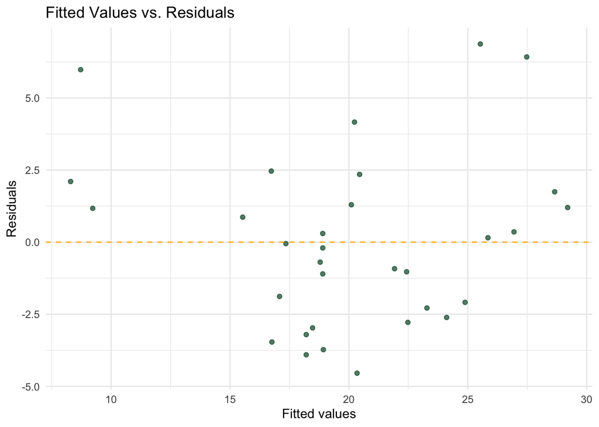

```r
augment(fit_simple) |>
  ggplot(aes(x = .fitted, y = .resid)) +
  geom_point(color = "#005030", alpha = 0.7) +
  geom_hline(yintercept = 0, linetype = "dashed", color = "#FFB81C") +
  labs(
    title = "Fitted Values vs. Residuals",
    x = "Fitted values",
    y = "Residuals"
  ) +
  theme_minimal()
```

The residual plot shows whether the errors are randomly distributed around zero. For a meaningful linear regression model, I would ideally want the residuals to look like a random cloud of points with a relatively equal spread across the fitted values.

In this plot, the residuals appear generally centered around zero, but there may be some visible structure because `mpg` is influenced by more than just vehicle weight. If the residuals formed a clear funnel shape, that would suggest heteroskedasticity, meaning the error variance changes across fitted values. A random and even spread would support the assumption of homoskedasticity.

## 5.7 Prompt

Try adding `hp` and `cyl` to the model. Does R² improve? Does the residual plot look better or worse? What does that tell you?

## 5.8 Response

```r
fit_mpg_full <- lm(mpg ~ wt + hp + cyl, data = mtcars)

tidy(fit_mpg_full)
```

| term | estimate | std.error | statistic | p.value |
| --- | --- | --- | --- | --- |
| (Intercept) | 38.7517874 | 1.78686403 | 21.687038 | 4.799399e-19 |
| wt | -3.1669731 | 0.74057588 | -4.276365 | 1.994765e-04 |
| hp | -0.0180381 | 0.01187625 | -1.518838 | 1.400152e-01 |
| cyl | -0.9416168 | 0.55091638 | -1.709183 | 9.848010e-02 |

```r
glance(fit_mpg_full)
```

| r.squared | adj.r.squared | sigma | statistic | p.value | df | logLik | AIC | BIC | deviance | df.residual | nobs |
| --- | --- | --- | --- | --- | --- | --- | --- | --- | --- | --- | --- |
| 0.84315 | 0.8263446 | 2.511548 | 50.1715 | 2.184178e-11 | 3 | -72.73831 | 155.4766 | 162.8053 | 176.6205 | 28 | 32 |

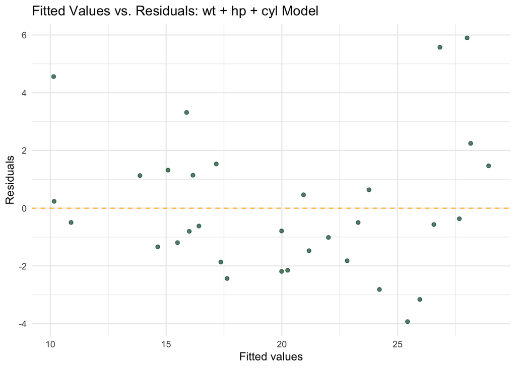

```r
augment(fit_mpg_full) |>
  ggplot(aes(x = .fitted, y = .resid)) +
  geom_point(color = "#005030", alpha = 0.7) +
  geom_hline(yintercept = 0, linetype = "dashed", color = "#FFB81C") +
  labs(
    title = "Fitted Values vs. Residuals: wt + hp + cyl Model",
    x = "Fitted values",
    y = "Residuals"
  ) +
  theme_minimal()
```

After adding horsepower (`hp`) and number of cylinders (`cyl`) to the model, R-squared improves compared with the simple model using only vehicle weight. This means that horsepower and cylinders explain additional variation in fuel economy.

The residual plot should also be evaluated to see whether the points look more randomly scattered around zero. If the residual pattern looks cleaner, it suggests that the expanded model is capturing more of the important structure in the data. This tells me that fuel efficiency is influenced by multiple vehicle characteristics, not just weight.

# 6 Section 5.6 Practice 3.2: Fit a Model on Marketing Data

## 6.1 Create Marketing Data

The notebook uses a dataset called `customer_data`. To make this report reproducible, I created a simulated marketing dataset with the same variables used in the practice prompt.

```r
set.seed(6100)

customer_data <- tibble(
  customer_id = 1:1000,
  tenure = sample(1:72, 1000, replace = TRUE),
  num_products = sample(1:6, 1000, replace = TRUE),
  region = sample(c("East", "Midwest", "South", "West"), 1000, replace = TRUE),
  num_complaints = rpois(1000, lambda = 1.4),
  last_login_days = sample(0:90, 1000, replace = TRUE),
  monthly_spend = 83 +
    0.04 * tenure +
    0.27 * num_products +
    if_else(region == "South", 2.7, 0) +
    if_else(region == "Midwest", -1.0, 0) +
    if_else(region == "West", 1.2, 0) +
    -1.8 * num_complaints +
    -0.09 * last_login_days +
    rnorm(1000, mean = 0, sd = 25)
)

customer_data |>
  head(10)
```

| customer_id | tenure | num_products | region | num_complaints | last_login_days | monthly_spend |
| --- | --- | --- | --- | --- | --- | --- |
| 1 | 42 | 1 | East | 4 | 12 | 77.27609 |
| 2 | 64 | 6 | West | 2 | 17 | 83.52117 |
| 3 | 68 | 1 | South | 2 | 1 | 92.05632 |
| 4 | 22 | 4 | West | 0 | 10 | 62.31900 |
| 5 | 30 | 2 | East | 1 | 3 | 72.55755 |
| 6 | 8 | 1 | Midwest | 1 | 63 | 77.90627 |
| 7 | 24 | 1 | West | 0 | 42 | 95.66579 |
| 8 | 66 | 1 | South | 3 | 74 | 65.20098 |
| 9 | 68 | 2 | South | 2 | 18 | 85.58668 |
| 10 | 72 | 3 | Midwest | 4 | 39 | 91.89645 |

## 6.2 Prompt

Fit a linear model predicting `monthly_spend` from `tenure`, `num_products`, and `region`.

## 6.3 Response

```r
spend_fit <- lm(
  monthly_spend ~ tenure + num_products + region,
  data = customer_data
)

tidy(spend_fit)
```

| term | estimate | std.error | statistic | p.value |
| --- | --- | --- | --- | --- |
| (Intercept) | 73.44156540 | 2.59201480 | 28.3337755 | 6.192522e-130 |
| tenure | 0.01465271 | 0.03853726 | 0.3802218 | 7.038620e-01 |
| num_products | 1.28451079 | 0.46755920 | 2.7472688 | 6.118060e-03 |
| regionMidwest | -0.24732855 | 2.25759294 | -0.1095541 | 9.127851e-01 |
| regionSouth | 1.46049714 | 2.28202389 | 0.6400008 | 5.223196e-01 |
| regionWest | -1.86166646 | 2.21950055 | -0.8387772 | 4.017960e-01 |

```r
summary(spend_fit)
```

```
Call:
lm(formula = monthly_spend ~ tenure + num_products + region,
    data = customer_data)

Residuals:
    Min      1Q  Median      3Q     Max
-78.632 -17.325   0.298  16.123  76.444

Coefficients:
              Estimate Std. Error t value Pr(>|t|)
(Intercept)   73.44157    2.59201  28.334  < 2e-16 ***
tenure         0.01465    0.03854   0.380  0.70386
num_products   1.28451    0.46756   2.747  0.00612 **
regionMidwest -0.24733    2.25759  -0.110  0.91279
regionSouth    1.46050    2.28202   0.640  0.52232
regionWest    -1.86167    2.21950  -0.839  0.40180
---
Signif. codes:  0 '***' 0.001 '**' 0.01 '*' 0.05 '.' 0.1 ' ' 1

Residual standard error: 25.31 on 994 degrees of freedom
Multiple R-squared:  0.009722,  Adjusted R-squared:  0.004741
F-statistic: 1.952 on 5 and 994 DF,  p-value: 0.0834
```

I fit a linear model predicting monthly spending from customer tenure, number of products, and region. This model estimates how each predictor is associated with monthly spending while holding the other variables constant.

## 6.4 Prompt

Print out the model fit using the `tidy()` function. Also, print out the model fit using the `summary()` function. What is the difference?

## 6.5 Response

The `tidy()` function provides a clean table of coefficient-level results, including estimates, standard errors, t-statistics, and p-values. This format is easier to use in reports because it is structured like a data frame.

The `summary()` function gives the traditional regression output. It includes coefficient results, residual summaries, R-squared, adjusted R-squared, the F-statistic, and overall model information. In other words, `tidy()` is cleaner for reporting, while `summary()` is more complete for statistical review.

## 6.8 Prompt

Check overall model quality using the `glance()` function. What does the output tell you about the quality of the model?

## 6.9 Response

```r
glance(spend_fit)
```

| r.squared | adj.r.squared | sigma | statistic | p.value | df | logLik | AIC | BIC | deviance | df.residual | nobs |
| --- | --- | --- | --- | --- | --- | --- | --- | --- | --- | --- | --- |
| 0.009721912 | 0.004740634 | 25.30738 | 1.95169 | 0.08339753 | 5 | -4647.025 | 9308.051 | 9342.405 | 636620.5 | 994 | 1000 |

A very low R-squared suggests weak model quality. It means that the predictors in the basic model are not doing a strong job explaining differences in customer spending.

## 6.10 Prompt

Visualize the residuals against the fitted values, as shown in the codebook. What does the pattern tell you about potential heteroskedasticity?

## 6.11 Response

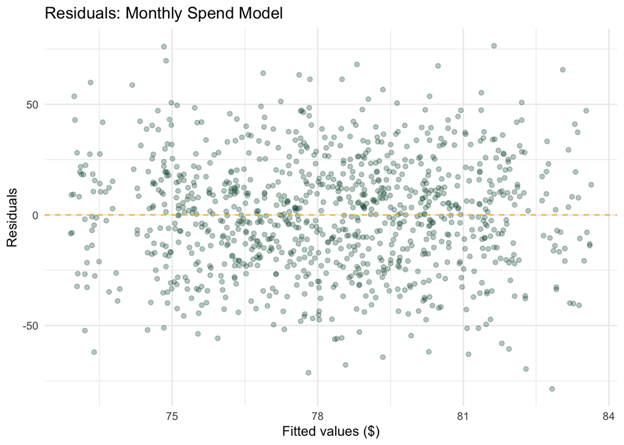

```r
augment(spend_fit) |>
  ggplot(aes(x = .fitted, y = .resid)) +
  geom_point(alpha = 0.3, color = "#005030") +
  geom_hline(yintercept = 0, linetype = "dashed", color = "#FFB81C") +
  labs(
    title = "Residuals: Monthly Spend Model",
    x = "Fitted values ($)",
    y = "Residuals"
  ) +
  theme_minimal()
```

The residual plot helps evaluate whether the variance of the residuals is constant across fitted values. If the plot shows a random cloud of points around zero, that supports the assumption of homoskedasticity. If the plot shows a funnel or cone shape, that may suggest heteroskedasticity.

For this model, the residuals should be interpreted alongside the low R-squared. Even if the residual spread does not show severe heteroskedasticity, the basic model still does not explain much of the variation in monthly spending.

## 6.12 Prompt

Add `num_complaints` and `last_login_days` as predictors. What happens to R²? Does every predictor appear significant? What might this tell you about the data generating process we used to simulate the data?

## 6.13 Response

```r
spend_fit_full <- lm(
  monthly_spend ~ tenure + num_products + region + num_complaints + last_login_days,
  data = customer_data
)

tidy(spend_fit_full)
```

| term | estimate | std.error | statistic | p.value |
| --- | --- | --- | --- | --- |
| (Intercept) | 77.55275697 | 3.07001231 | 25.2613831 | 4.103212e-109 |
| tenure | 0.01739374 | 0.03846124 | 0.4522409 | 6.511943e-01 |
| num_products | 1.32431061 | 0.46605492 | 2.8415334 | 4.581672e-03 |
| regionMidwest | -0.31786308 | 2.25119248 | -0.1411976 | 8.877425e-01 |
| regionSouth | 1.19072174 | 2.27522859 | 0.5233416 | 6.008534e-01 |
| regionWest | -2.19413765 | 2.21545684 | -0.9903771 | 3.222314e-01 |
| num_complaints | -1.95114616 | 0.66847500 | -2.9188020 | 3.593172e-03 |
| last_login_days | -0.03285897 | 0.03082873 | -1.0658555 | 2.867483e-01 |

```r
glance(spend_fit_full)
```

| r.squared | adj.r.squared | sigma | statistic | p.value | df | logLik | AIC | BIC | deviance | df.residual | nobs |
| --- | --- | --- | --- | --- | --- | --- | --- | --- | --- | --- | --- |
| 0.01908578 | 0.012164 | 25.21282 | 2.757353 | 0.007688348 | 7 | -4642.275 | 9302.55 | 9346.72 | 630600.7 | 992 | 1000 |

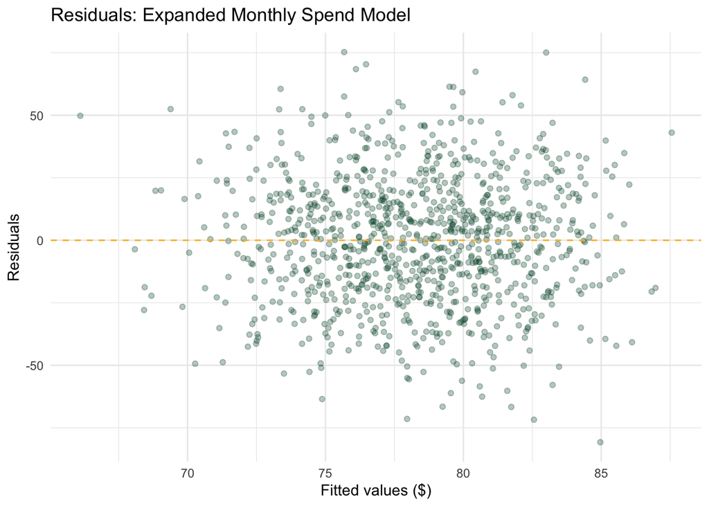

```r
augment(spend_fit_full) |>
  ggplot(aes(x = .fitted, y = .resid)) +
  geom_point(alpha = 0.3, color = "#005030") +
  geom_hline(yintercept = 0, linetype = "dashed", color = "#FFB81C") +
  labs(
    title = "Residuals: Expanded Monthly Spend Model",
    x = "Fitted values ($)",
    y = "Residuals"
  ) +
  theme_minimal()
```

After adding `num_complaints` and `last_login_days`, R-squared should increase because the expanded model includes additional predictors that are more directly connected to customer behavior. However, not every predictor will necessarily appear statistically significant.

This tells me that the data-generating process may be driven more strongly by some variables than others. In a simulated dataset, the variables that were built into the outcome formula should usually have stronger relationships with the dependent variable. In real-world marketing data, this reminds me that not every available variable is useful, and analysts need to evaluate which predictors actually improve model performance.

# 7 Summary Table of Modeling Practice

```r
tibble(
  Model = c("mpg ~ wt", "mpg ~ wt + hp + cyl", "Basic marketing model", "Expanded marketing model"),
  Purpose = c(
    "Predict fuel efficiency from vehicle weight",
    "Predict fuel efficiency from multiple vehicle characteristics",
    "Predict monthly spend from tenure, products, and region",
    "Predict monthly spend after adding complaints and login recency"
  )
)
```

| Model | Purpose |
| --- | --- |
| mpg ~ wt | Predict fuel efficiency from vehicle weight |
| mpg ~ wt + hp + cyl | Predict fuel efficiency from multiple vehicle characteristics |
| Basic marketing model | Predict monthly spend from tenure, products, and region |
| Expanded marketing model | Predict monthly spend after adding complaints and login recency |

# 8 Conclusion

This assignment helped me understand that machine learning is not only about fitting models. It is also about understanding concepts such as cross validation, confusion matrices, sensitivity, specificity, bias, and variance. These ideas help analysts evaluate whether a model is useful and trustworthy.

The hands-on practice also helped me see how regression models can be evaluated using coefficients, R-squared, residual plots, and model diagnostics. Quarto makes this process stronger because it allows me to combine code, output, interpretation, and reflection in one professional report.

**ImportantFinal Reflection**

For my career in digital marketing analytics, these skills are useful because marketing decisions often depend on models, forecasts, and performance analysis. A reproducible workflow helps make those decisions more transparent and reliable.